### Github Repository link : “https://github.com/Nini099/SLE-712”

### Part 1: Importing files, data wrangling, mathematical operations, plots and saving code on GitHub

##Question 1 : Read in the file, making the gene accession numbers the row names. Show a table of values for the first six genes ###Answer:

```r
download.file("https://raw.githubusercontent.com/markziemann/SLE712_files/master/bioinfo_asst3_part1_files/gene_expression.tsv", destfile = "gene_expression.tsv" )
x<- read.table("data/gene_expression.tsv", header = TRUE, stringsAsFactors = FALSE, row.names = 1)
head(x)
```

```
##                 SRR5150592 SRR5150593
## ENSG00000223972          1          0
## ENSG00000227232          0          1
## ENSG00000278267          0          0
## ENSG00000243485          0          0
## ENSG00000284332          0          0
## ENSG00000237613          0          0
```

```r
str(x)
```

```
## 'data.frame':    58302 obs. of  2 variables:
##  $ SRR5150592: int  1 0 0 0 0 0 0 0 0 0 ...
##  $ SRR5150593: int  0 1 0 0 0 0 0 0 0 0 ...
```

```r
x[1:6,1:2]
```

```
##                 SRR5150592 SRR5150593
## ENSG00000223972          1          0
## ENSG00000227232          0          1
## ENSG00000278267          0          0
## ENSG00000243485          0          0
## ENSG00000284332          0          0
## ENSG00000237613          0          0
```

The row names were changed into gene accession number while naming the table as x ##Question 2 : Make a new column which is the mean of the other columns. Show a table of values for the first six genes ###Answer:

```r
x$Mean_cal <- rowMeans(x)
head(x)
```

```
##                 SRR5150592 SRR5150593 Mean_cal
## ENSG00000223972          1          0      0.5
## ENSG00000227232          0          1      0.5
## ENSG00000278267          0          0      0.0
## ENSG00000243485          0          0      0.0
## ENSG00000284332          0          0      0.0
## ENSG00000237613          0          0      0.0
```

```r
x[1:6,1:3]
```

```
##                 SRR5150592 SRR5150593 Mean_cal
## ENSG00000223972          1          0      0.5
## ENSG00000227232          0          1      0.5
## ENSG00000278267          0          0      0.0
## ENSG00000243485          0          0      0.0
## ENSG00000284332          0          0      0.0
## ENSG00000237613          0          0      0.0
```

A new column “Mean_cal” is created that holds the mean value of the other columns.

##Question3. List the 10 genes with the highest mean expression ###Answer:

```r
Highest_mean <-x[order(-x$Mean_cal),]
head(Highest_mean,10)
```

```
##                 SRR5150592 SRR5150593 Mean_cal
## ENSG00000115414     311857     206347 259102.0
## ENSG00000210082     145916     163288 154602.0
## ENSG00000075624     133983     116762 125372.5
## ENSG00000198886      91596      99943  95769.5
## ENSG00000137801      95158      74546  84852.0
## ENSG00000198804      79832      84774  82303.0
## ENSG00000198786      74570      83589  79079.5
## ENSG00000196924      88225      66413  77319.0
## ENSG00000198712      76108      77108  76608.0
## ENSG00000108821      80342      60127  70234.5
```

##Question 4.Determine the number of genes with a mean <10 ###Answer:

```r
filteredmean <- subset(x,Mean_cal<10)
nrow(filteredmean)
```

```
## [1] 43124
```

##Question 5. Make a histogram plot of the mean values in png format and paste it into your report ###Answer:

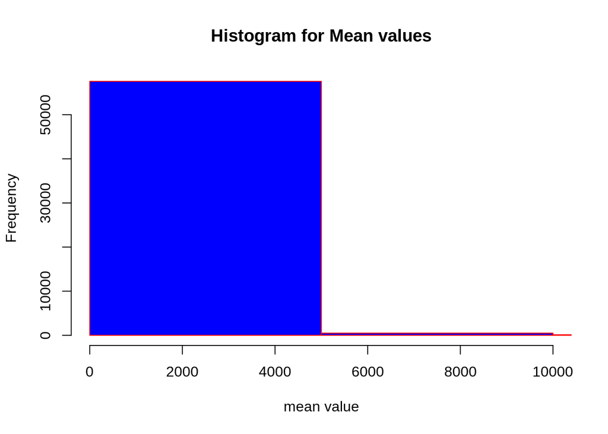

##Question 6. Import this csv file into an R object. What are the column names? ###Answer:The CSV files were uploaded from the link The “csv” file was saved as obejct “y”.

```r
download.file("https://raw.githubusercontent.com/markziemann/SLE712_files/master/bioinfo_asst3_part1_files/growth_data.csv",destfile = "growth_data.csv")
y <- read.csv("data/growth_data.csv", header = TRUE, stringsAsFactors = FALSE)
head(y)
```

```
##        Site TreeID Circumf_2004_cm Circumf_2009_cm Circumf_2014_cm
## 1 northeast   A003             5.2            10.1            19.9
## 2 northeast   A005             4.9             9.6            18.9
## 3 northeast   A007             3.7             7.3            14.3
## 4 northeast   A008             3.8             6.5            10.9
## 5 northeast   A011             3.8             6.4            10.9
## 6 northeast   A012             5.9            10.0            16.8
##   Circumf_2019_cm
## 1            38.9
## 2            37.0
## 3            28.1
## 4            18.5
## 5            18.4
## 6            28.4
```

```r
str(y)
```

```
## 'data.frame':    100 obs. of  6 variables:
##  $ Site           : chr  "northeast" "northeast" "northeast" "northeast" ...
##  $ TreeID         : chr  "A003" "A005" "A007" "A008" ...
##  $ Circumf_2004_cm: num  5.2 4.9 3.7 3.8 3.8 5.9 4.4 5.3 7.1 3.8 ...
##  $ Circumf_2009_cm: num  10.1 9.6 7.3 6.5 6.4 10 9.9 9 12 7.4 ...
##  $ Circumf_2014_cm: num  19.9 18.9 14.3 10.9 10.9 16.8 22.2 15.2 20.2 14.5 ...
##  $ Circumf_2019_cm: num  38.9 37 28.1 18.5 18.4 28.4 50 25.8 34.2 28.4 ...
```

###Name of the columns are- “site”, “TreeID”,“Circumf_2004_cm”, “Circumf_2009_cm”, “Circumf_2014_cm” and “Circumf_2019_cm”

##Question 7 Calculate the mean and standard deviation of tree circumference at the start and end of the study at both sites.

```r
NE <- subset(y,Site=="northeast")
SW <- subset(y,Site=="southwest")
head(NE)
```

```
##        Site TreeID Circumf_2004_cm Circumf_2009_cm Circumf_2014_cm
## 1 northeast   A003             5.2            10.1            19.9
## 2 northeast   A005             4.9             9.6            18.9
## 3 northeast   A007             3.7             7.3            14.3
## 4 northeast   A008             3.8             6.5            10.9
## 5 northeast   A011             3.8             6.4            10.9
## 6 northeast   A012             5.9            10.0            16.8
##   Circumf_2019_cm
## 1            38.9
## 2            37.0
## 3            28.1
## 4            18.5
## 5            18.4
## 6            28.4
```

```r
head(SW)
```

```
##         Site TreeID Circumf_2004_cm Circumf_2009_cm Circumf_2014_cm
## 51 southwest   A001             5.3            13.5            34.6
## 52 southwest   A002             5.2            10.1            19.8
## 53 southwest   A004             6.2            15.9            40.6
## 54 southwest   A006             5.1            11.5            25.9
## 55 southwest   A009             3.6             9.1            23.4
## 56 southwest   A010             6.6            14.9            33.6
##    Circumf_2019_cm
## 51            88.7
## 52            38.8
## 53           103.9
## 54            58.3
## 55            59.8
## 56            75.5
```

###Mean calculation of tree circumference at the start and end of the study for North East Site

```r
mean(NE$Circumf_2004_cm)
```

```
## [1] 5.078
```

```r
mean(NE$Circumf_2019_cm)
```

```
## [1] 40.052
```

```r
sd(NE$Circumf_2004_cm)
```

```
## [1] 1.059127
```

```r
sd(NE$Circumf_2019_cm)
```

```
## [1] 16.90443
```

Mean and standard deviation calculation of tree circumfurence at the satrt and end of the site Southwest

```r
mean(SW$Circumf_2004_cm)
```

```
## [1] 5.076
```

```r
mean(SW$Circumf_2019_cm)
```

```
## [1] 59.772
```

```r
sd(SW$Circumf_2004_cm)
```

```
## [1] 1.060527
```

```r
sd(SW$Circumf_2019_cm)
```

```
## [1] 22.57784
```

##Question 8 Make a box plot of tree circumference at the start and end of the study at both sites.

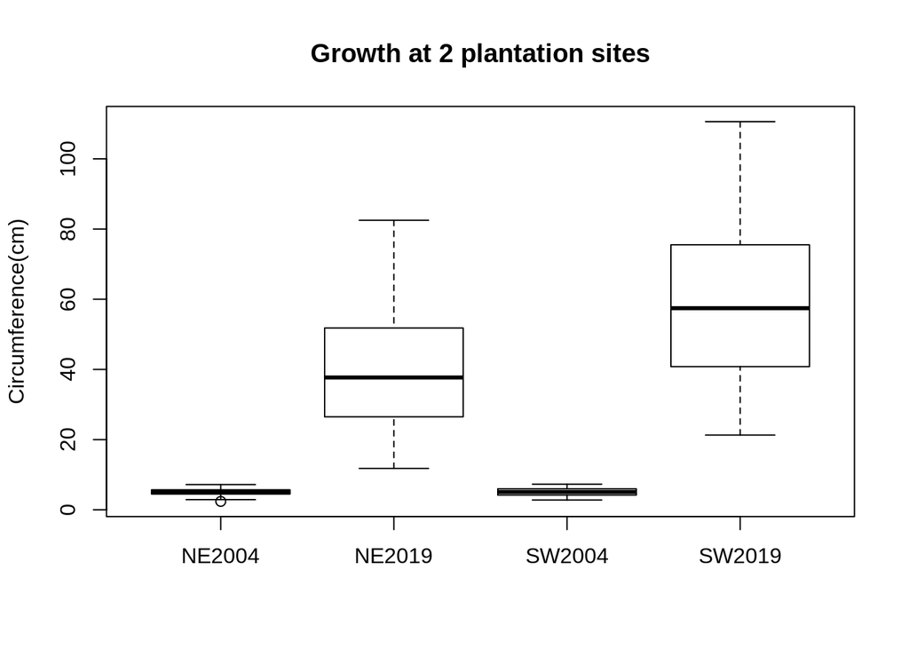

```r
boxplot(NE$Circumf_2004_cm,NE$Circumf_2019_cm,SW$Circumf_2004_cm,SW$Circumf_2019_cm,names=c("NE2004","NE2019","SW2004","SW2019"),ylab="Circumference(cm)",main="Growth at 2 plantation sites")
```

##Question 9 Calculate the mean growth over the past 10 years at each site. ###Answer: For calculating mean growth for past 10 years in each site, two seperate columns were created.

```r
NE$Growth <- (NE$Circumf_2019_cm-NE$Circumf_2009_cm )
head(NE)
```

```
##        Site TreeID Circumf_2004_cm Circumf_2009_cm Circumf_2014_cm
## 1 northeast   A003             5.2            10.1            19.9
## 2 northeast   A005             4.9             9.6            18.9
## 3 northeast   A007             3.7             7.3            14.3
## 4 northeast   A008             3.8             6.5            10.9
## 5 northeast   A011             3.8             6.4            10.9
## 6 northeast   A012             5.9            10.0            16.8
##   Circumf_2019_cm Growth
## 1            38.9   28.8
## 2            37.0   27.4
## 3            28.1   20.8
## 4            18.5   12.0
## 5            18.4   12.0
## 6            28.4   18.4
```

```r
SW$Growth <- (SW$Circumf_2019_cm-SW$Circumf_2009_cm)
head(SW)
```

```
##         Site TreeID Circumf_2004_cm Circumf_2009_cm Circumf_2014_cm
## 51 southwest   A001             5.3            13.5            34.6
## 52 southwest   A002             5.2            10.1            19.8
## 53 southwest   A004             6.2            15.9            40.6
## 54 southwest   A006             5.1            11.5            25.9
## 55 southwest   A009             3.6             9.1            23.4
## 56 southwest   A010             6.6            14.9            33.6
##    Circumf_2019_cm Growth
## 51            88.7   75.2
## 52            38.8   28.7
## 53           103.9   88.0
## 54            58.3   46.8
## 55            59.8   50.7
## 56            75.5   60.6
```

##Question 10 Use the t.test and wilcox.test functions to estimate the p-value that the 10 year growth is different at the two site ###Answer: For t.test and wilcox.test, the columns that demonstrated mean growth values for past 10 years

**t.test**

```r
t.test(SW$Growth,NE$Growth)
```

```
##
##  Welch Two Sample t-test
##
## data:  SW$Growth and NE$Growth
## t = 5.124, df = 89.366, p-value = 1.713e-06
## alternative hypothesis: true difference in means is not equal to 0
## 95 percent confidence interval:
##  11.19057 25.36543
## sample estimates:
## mean of x mean of y
##    48.354    30.076
```

**wolcox.test**

```r
wilcox.test(SW$Growth,NE$Growth)
```

```
##
##  Wilcoxon rank sum test with continuity correction
##
## data:  SW$Growth and NE$Growth
## W = 1915, p-value = 4.626e-06
## alternative hypothesis: true location shift is not equal to 0
```

##the P-value for t-test is 1.713e-06, and for Wilcox test it is 4.626e-06